# Diabetes prediction with Naive Bayes: exploratory analysis of the variables

# 1 Dataset and variables

The data is the Pima Indians Diabetes dataset (768 women, `diabetes.csv`). Each row is one patient; the goal is to predict `Outcome` (diabetes: 1 = yes, 0 = no) from 8 medical predictors.

| Variable | Meaning |
| --- | --- |
| `Pregnancies` | Number of pregnancies |
| `Glucose` | Plasma glucose concentration (2-hour oral glucose tolerance test) |
| `BloodPressure` | Diastolic blood pressure (mm Hg) |
| `SkinThickness` | Triceps skinfold thickness (mm) |
| `Insulin` | 2-hour serum insulin (mu U/ml) |
| `BMI` | Body mass index (kg/m²) |
| `DiabetesPedigreeFunction` | Score of diabetes family history |
| `Age` | Age (years) |
| `Outcome` | **Response:** diabetes yes/no |

# 2 Data preparation

```r
diab <- read.csv("diabetes.csv")
str(diab)
```

```
## 'data.frame':    768 obs. of  9 variables:
##  $ Pregnancies             : int  6 1 8 1 0 5 3 10 2 8 ...
##  $ Glucose                 : int  148 85 183 89 137 116 78 115 197 125 ...
##  $ BloodPressure           : int  72 66 64 66 40 74 50 0 70 96 ...
##  $ SkinThickness           : int  35 29 0 23 35 0 32 0 45 0 ...
##  $ Insulin                 : int  0 0 0 94 168 0 88 0 543 0 ...
##  $ BMI                     : num  33.6 26.6 23.3 28.1 43.1 25.6 31 35.3 30.5 0 ...
##  $ DiabetesPedigreeFunction: num  0.627 0.351 0.672 0.167 2.288 ...
##  $ Age                     : int  50 31 32 21 33 30 26 29 53 54 ...
##  $ Outcome                 : int  1 0 1 0 1 0 1 0 1 1 ...
```

```r
diab$Outcome <- factor(diab$Outcome, levels = c(0, 1), labels = c("No diabetes", "Diabetes"))
predictors <- names(diab)[1:8]

# Zero is impossible for these variables -> it is a disguised missing value
zero_vars <- c("Glucose", "BloodPressure", "SkinThickness", "Insulin", "BMI")
cat("Zeros in each variable:\n"); print(colSums(diab[predictors] == 0))
```

```
## Zeros in each variable:
```

```
##              Pregnancies                  Glucose            BloodPressure
##                      111                        5                       35
##            SkinThickness                  Insulin                      BMI
##                      227                      374                       11
## DiabetesPedigreeFunction                      Age
##                        0                        0
```

```r
for (v in zero_vars) diab[[v]][diab[[v]] == 0] <- NA
miss <- data.frame(Variable = predictors,
                   Missing = colSums(is.na(diab[predictors])),
                   Percent = round(100 * colMeans(is.na(diab[predictors])), 1))
rownames(miss) <- NULL
knitr::kable(miss[miss$Missing > 0, ], caption = "Variables with hidden missing values (zeros replaced by NA)")
```

Variables with hidden missing values (zeros replaced by NA)

|  | Variable | Missing | Percent |
| --- | --- | --- | --- |
| 2 | Glucose | 5 | 0.7 |
| 3 | BloodPressure | 35 | 4.6 |
| 4 | SkinThickness | 227 | 29.6 |
| 5 | Insulin | 374 | 48.7 |
| 6 | BMI | 11 | 1.4 |

**Decision.** A glucose, blood pressure, skinfold, insulin or BMI of 0 is physiologically impossible, so these zeros are treated as missing (`NA`) in the analysis. `Pregnancies = 0` is valid and is kept. No rows are deleted; every statistic below uses the available values of each variable. `Insulin` (48.7%) and `SkinThickness` (29.6%) have a very large share of missing values, which matters for the choice of variables (see the conclusions). If the zeros were left as they are, they would pull the means down and distort the Gaussian densities that Naive Bayes estimates.

```r
skewness <- function(x) { x <- x[!is.na(x)]; mean((x - mean(x))^3) / sd(x)^3 }

get_stats <- function(x) {
  x <- x[!is.na(x)]
  c(N = length(x), Mean = mean(x), Median = median(x), SD = sd(x),
    Min = min(x), Q1 = unname(quantile(x, .25)), Q3 = unname(quantile(x, .75)),
    Max = max(x), Skewness = skewness(x))
}

# long format for faceted plots
long <- do.call(rbind, lapply(predictors, function(v)
  data.frame(Variable = v, Value = diab[[v]], Outcome = diab$Outcome)))
long$Variable <- factor(long$Variable, levels = predictors)
long <- long[!is.na(long$Value), ]
```

# 3 Response variable

```r
tb <- table(diab$Outcome)
knitr::kable(data.frame(Class = names(tb), Count = as.integer(tb),
                        Percent = round(100 * prop.table(tb), 1)),
             caption = "Distribution of Outcome")
```

Distribution of Outcome

| Class | Count | Percent.Var1 | Percent.Freq |
| --- | --- | --- | --- |
| No diabetes | 500 | No diabetes | 65.1 |
| Diabetes | 268 | Diabetes | 34.9 |

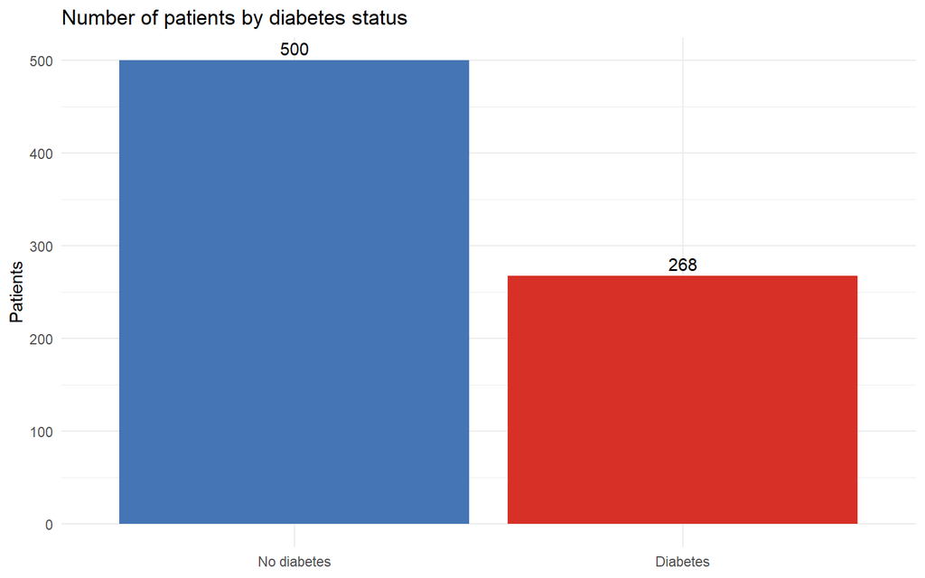

```r
ggplot(diab, aes(x = Outcome, fill = Outcome)) +
  geom_bar(show.legend = FALSE) +
  geom_text(stat = "count", aes(label = after_stat(count)), vjust = -0.4) +
  scale_fill_manual(values = col_y) +
  labs(title = "Number of patients by diabetes status", x = NULL, y = "Patients")
```

34.9% of the patients have diabetes, so the classes are moderately imbalanced. For Naive Bayes this matters because the **prior probability** P(diabetes) equals this share. A classifier that always answers “no diabetes” would already be about 65% accurate, so accuracy alone is not a good measure; sensitivity and specificity should also be reported.

# 4 Descriptive statistics of the predictors

```r
desc <- t(sapply(predictors, function(v) get_stats(diab[[v]])))
knitr::kable(round(desc, 2), caption = "Descriptive statistics (missing values excluded)")
```

Descriptive statistics (missing values excluded)

|  | N | Mean | Median | SD | Min | Q1 | Q3 | Max | Skewness |
| --- | --- | --- | --- | --- | --- | --- | --- | --- | --- |
| Pregnancies | 768 | 3.85 | 3.00 | 3.37 | 0.00 | 1.00 | 6.00 | 17.00 | 0.90 |
| Glucose | 763 | 121.69 | 117.00 | 30.54 | 44.00 | 99.00 | 141.00 | 199.00 | 0.53 |
| BloodPressure | 733 | 72.41 | 72.00 | 12.38 | 24.00 | 64.00 | 80.00 | 122.00 | 0.13 |
| SkinThickness | 541 | 29.15 | 29.00 | 10.48 | 7.00 | 22.00 | 36.00 | 99.00 | 0.69 |
| Insulin | 394 | 155.55 | 125.00 | 118.78 | 14.00 | 76.25 | 190.00 | 846.00 | 2.15 |
| BMI | 757 | 32.46 | 32.30 | 6.92 | 18.20 | 27.50 | 36.60 | 67.10 | 0.59 |
| DiabetesPedigreeFunction | 768 | 0.47 | 0.37 | 0.33 | 0.08 | 0.24 | 0.63 | 2.42 | 1.91 |
| Age | 768 | 33.24 | 29.00 | 11.76 | 21.00 | 24.00 | 41.00 | 81.00 | 1.13 |

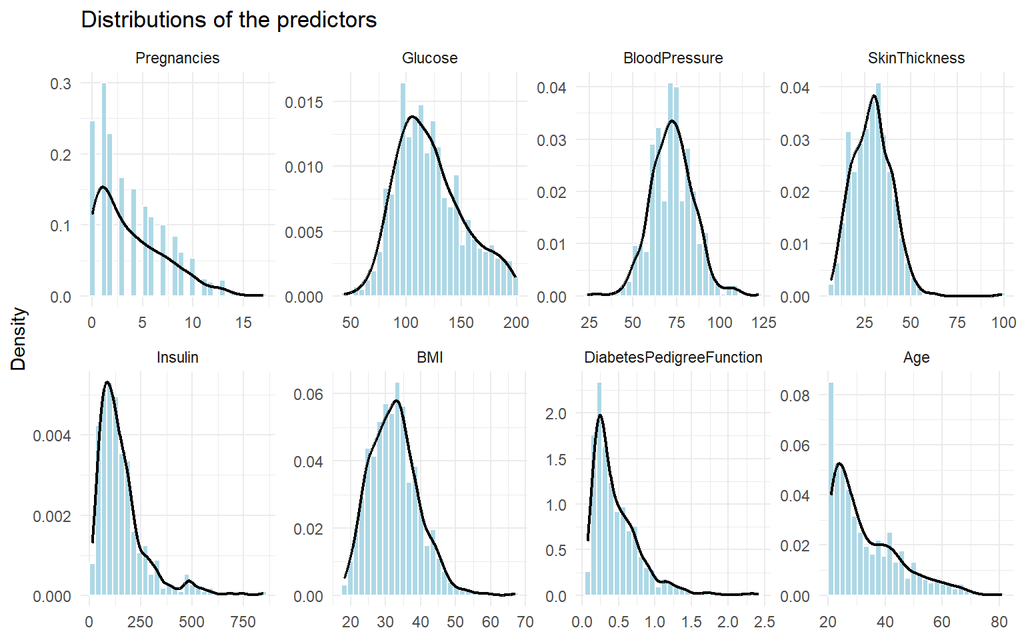

```r
ggplot(long, aes(x = Value)) +
  geom_histogram(aes(y = after_stat(density)), bins = 30, fill = "lightblue", colour = "white") +
  geom_density(linewidth = 0.8) +
  facet_wrap(~ Variable, scales = "free", ncol = 4) +
  labs(title = "Distributions of the predictors", x = NULL, y = "Density")
```

`Glucose` and `BloodPressure` are close to symmetric (mean ≈ median, low skewness) and `BMI` is only mildly right-skewed. `Pregnancies`, `Age`, `DiabetesPedigreeFunction` and especially `Insulin` are strongly right-skewed (long tail of large values, mean clearly above the median), so for them the median and IQR describe the typical patient better than the mean.

# 5 Why these variables? Predictors by diabetes status

A variable is useful for Naive Bayes if its distribution is **different** in the two classes. The table measures this by the difference of group means in standard deviations (Cohen’s d, larger |d| = better separation) and by the Wilcoxon rank-sum test.

```r
eff <- do.call(rbind, lapply(predictors, function(v) {
  a <- diab[[v]][diab$Outcome == "No diabetes"]; a <- a[!is.na(a)]
  b <- diab[[v]][diab$Outcome == "Diabetes"];    b <- b[!is.na(b)]
  sp <- sqrt(((length(a) - 1) * var(a) + (length(b) - 1) * var(b)) / (length(a) + length(b) - 2))
  data.frame(Variable = v,
             `Mean (no diabetes)` = mean(a), `Mean (diabetes)` = mean(b),
             `Median (no diabetes)` = median(a), `Median (diabetes)` = median(b),
             `Cohen d` = (mean(b) - mean(a)) / sp,
             `Wilcoxon p-value` = wilcox.test(a, b)$p.value,
             check.names = FALSE)
}))
eff <- eff[order(-abs(eff$`Cohen d`)), ]
eff$`Wilcoxon p-value` <- format.pval(eff$`Wilcoxon p-value`, digits = 2, eps = 1e-10)
knitr::kable(eff, digits = 2, row.names = FALSE,
             caption = "Predictors ranked by the strength of the difference between the classes")
```

Predictors ranked by the strength of the difference between the classes

| Variable | Mean (no diabetes) | Mean (diabetes) | Median (no diabetes) | Median (diabetes) | Cohen d | Wilcoxon p-value |
| --- | --- | --- | --- | --- | --- | --- |
| Glucose | 110.64 | 142.32 | 107.00 | 140.00 | 1.19 | < 1e-10 |
| BMI | 30.86 | 35.41 | 30.10 | 34.30 | 0.69 | < 1e-10 |
| Insulin | 130.29 | 206.85 | 102.50 | 169.50 | 0.68 | < 1e-10 |
| SkinThickness | 27.24 | 33.00 | 27.00 | 32.00 | 0.57 | 7.0e-10 |
| Age | 31.19 | 37.07 | 27.00 | 36.00 | 0.51 | < 1e-10 |
| Pregnancies | 3.30 | 4.87 | 2.00 | 4.00 | 0.48 | 3.7e-08 |
| DiabetesPedigreeFunction | 0.43 | 0.55 | 0.34 | 0.45 | 0.37 | 1.2e-06 |
| BloodPressure | 70.88 | 75.32 | 70.00 | 74.50 | 0.36 | 1.6e-06 |

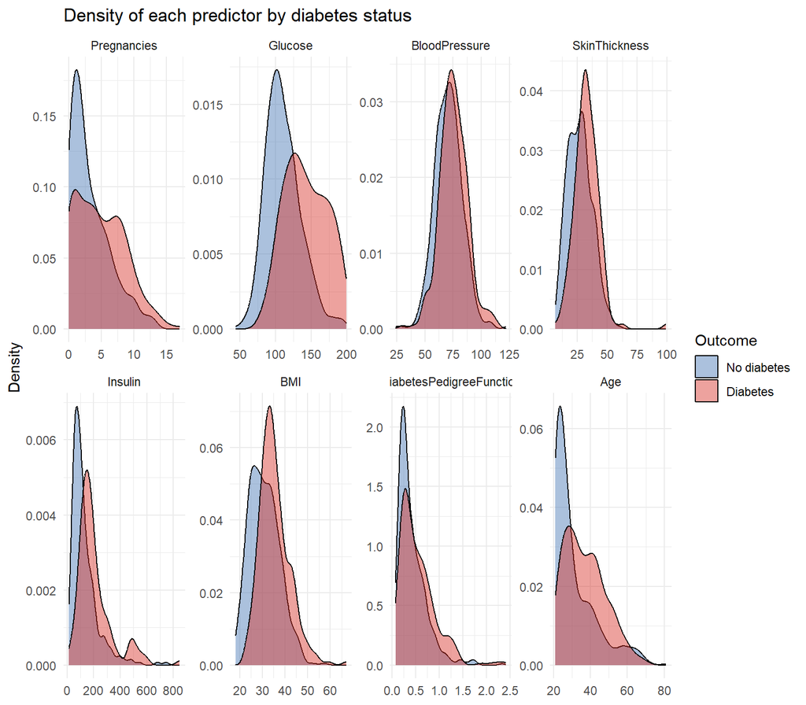

```r
ggplot(long, aes(x = Value, fill = Outcome)) +
  geom_density(alpha = 0.45) +
  facet_wrap(~ Variable, scales = "free", ncol = 4) +
  scale_fill_manual(values = col_y) +
  labs(title = "Density of each predictor by diabetes status", x = NULL, y = "Density")
```

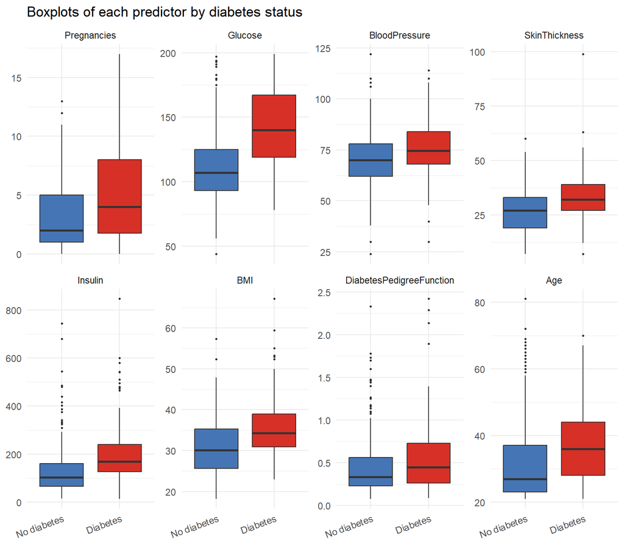

```r
ggplot(long, aes(x = Outcome, y = Value, fill = Outcome)) +
  geom_boxplot(outlier.size = 0.5, show.legend = FALSE) +
  facet_wrap(~ Variable, scales = "free_y", ncol = 4) +
  scale_fill_manual(values = col_y) +
  labs(title = "Boxplots of each predictor by diabetes status", x = NULL, y = NULL) +
  theme(axis.text.x = element_text(angle = 20, hjust = 1))
```

**Interpretation.**

- **`Glucose` is by far the best separator** (the largest |d|): the density curves of the two classes are clearly shifted and the boxes barely overlap in the middle. This is also medically expected, since glucose is the diagnostic criterion of diabetes.
- **`BMI`, `Insulin`, `SkinThickness`, `Age` and `Pregnancies`** show moderate separation: patients with diabetes are on average heavier, older, had more pregnancies and have higher insulin and skinfold values, but the distributions overlap a lot.
- **`DiabetesPedigreeFunction` and `BloodPressure`** differ least between the classes. Their effects are small but statistically detectable, so they are weak predictors.
- All predictors differ significantly between the classes (very small p-values), but statistical significance only says the difference exists; |d| shows how large it is.

# 6 Relationships between the predictors

Naive Bayes assumes that the predictors are **conditionally independent given the class**. Strong correlations between predictors violate this assumption, so they must be checked.

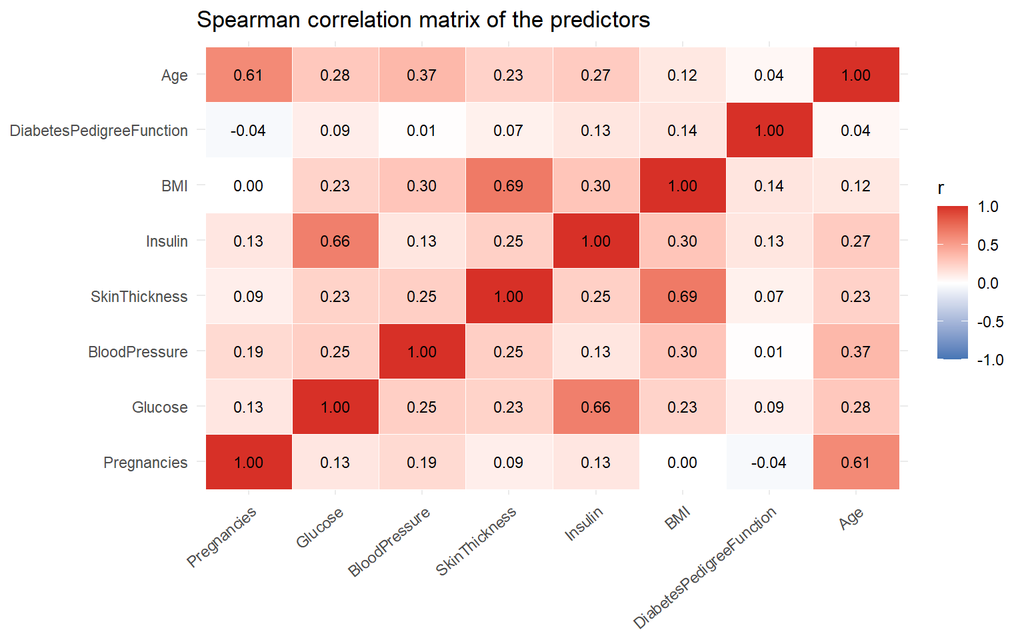

```r
cp <- cor(diab[predictors], use = "pairwise.complete.obs")
cs <- cor(diab[predictors], use = "pairwise.complete.obs", method = "spearman")

cd <- as.data.frame(as.table(cs)); names(cd) <- c("V1", "V2", "r")
ggplot(cd, aes(V1, V2, fill = r)) +
  geom_tile(colour = "white") +
  geom_text(aes(label = sprintf("%.2f", r)), size = 3) +
  scale_fill_gradient2(low = "#4575b4", mid = "white", high = "#d73027", limits = c(-1, 1)) +
  labs(title = "Spearman correlation matrix of the predictors", x = NULL, y = NULL, fill = "r") +
  theme(axis.text.x = element_text(angle = 40, hjust = 1))
```

```r
pairs_idx <- which(upper.tri(cp), arr.ind = TRUE)
pair_tab <- data.frame(Pair = paste(predictors[pairs_idx[, 1]], "and", predictors[pairs_idx[, 2]]),
                       Pearson = cp[pairs_idx], Spearman = cs[pairs_idx])
pair_tab <- pair_tab[order(-abs(pair_tab$Spearman)), ]
knitr::kable(head(pair_tab, 5), digits = 2, row.names = FALSE,
             caption = "Five most strongly correlated pairs of predictors")
```

Five most strongly correlated pairs of predictors

| Pair | Pearson | Spearman |
| --- | --- | --- |
| SkinThickness and BMI | 0.65 | 0.69 |
| Glucose and Insulin | 0.58 | 0.66 |
| Pregnancies and Age | 0.54 | 0.61 |
| BloodPressure and Age | 0.33 | 0.37 |
| Insulin and BMI | 0.23 | 0.30 |

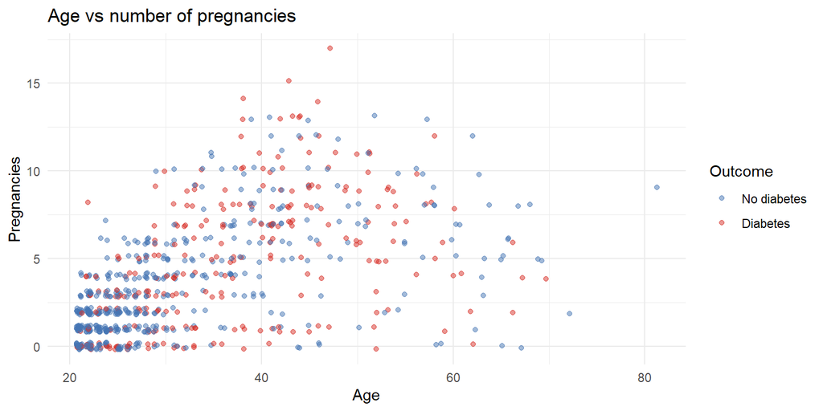

```r
ggplot(diab, aes(x = Age, y = Pregnancies, colour = Outcome)) +
  geom_jitter(alpha = 0.5, width = 0.3, height = 0.2) +
  scale_colour_manual(values = col_y) +
  labs(title = "Age vs number of pregnancies")
```

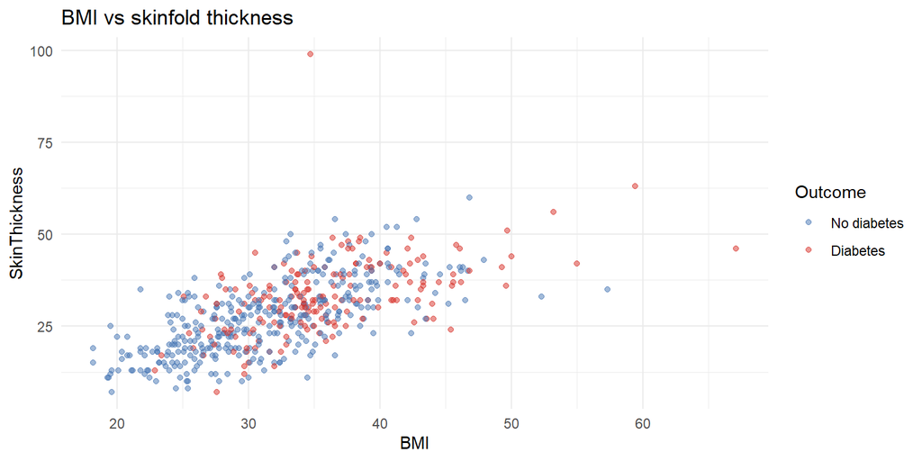

```r
ggplot(diab, aes(x = BMI, y = SkinThickness, colour = Outcome)) +
  geom_point(alpha = 0.5) +
  scale_colour_manual(values = col_y) +
  labs(title = "BMI vs skinfold thickness")
```

**Interpretation.** Most pairs are only weakly correlated, which is good for Naive Bayes. Three pairs are clearly related:

- **`BMI` and `SkinThickness`** (0.69): both measure body fat, so they carry largely the same information.
- **`Glucose` and `Insulin`** (0.66): insulin is released in response to glucose.
- **`Age` and `Pregnancies`** (0.61): older women have naturally had more pregnancies.

If both variables of such a pair are used, the same information is counted twice and the Naive Bayes probabilities become overconfident. This is a reason to consider keeping only one variable from each pair (for example, `BMI` instead of `SkinThickness`, which also has far fewer missing values).

# 7 Shape of the distributions within the classes

Gaussian Naive Bayes models each predictor in each class by a Normal distribution, so we check how close to Normal the within-class distributions are.

```r
sk <- do.call(rbind, lapply(predictors, function(v)
  data.frame(Variable = v,
             `Skewness (no diabetes)` = skewness(diab[[v]][diab$Outcome == "No diabetes"]),
             `Skewness (diabetes)`    = skewness(diab[[v]][diab$Outcome == "Diabetes"]),
             check.names = FALSE)))
knitr::kable(sk, digits = 2, caption = "Skewness of each predictor within the classes (0 = symmetric)")
```

Skewness of each predictor within the classes (0 = symmetric)

| Variable | Skewness (no diabetes) | Skewness (diabetes) |
| --- | --- | --- |
| Pregnancies | 1.11 | 0.50 |
| Glucose | 0.65 | 0.09 |
| BloodPressure | 0.16 | 0.08 |
| SkinThickness | 0.36 | 1.40 |
| Insulin | 2.48 | 1.84 |
| BMI | 0.47 | 1.01 |
| DiabetesPedigreeFunction | 1.99 | 1.70 |
| Age | 1.56 | 0.58 |

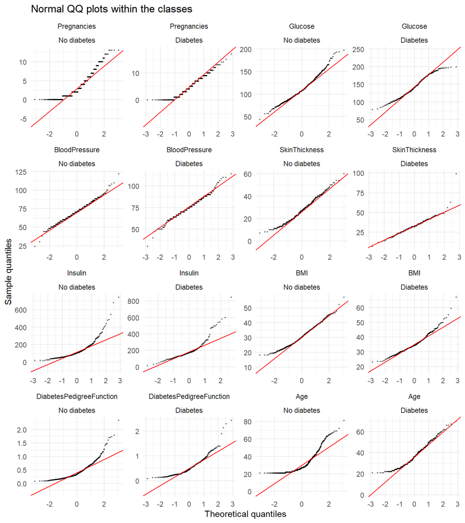

```r
ggplot(long, aes(sample = Value)) +
  stat_qq(size = 0.4, alpha = 0.5) + stat_qq_line(colour = "red") +
  facet_wrap(~ Variable + Outcome, scales = "free", ncol = 4) +
  labs(title = "Normal QQ plots within the classes", x = "Theoretical quantiles", y = "Sample quantiles")
```

**Interpretation.** `Glucose` and `BloodPressure` follow the line well in the central part, so the Normal assumption is reasonable for them (the deviations are in the tails). `BMI` is also fairly close to Normal, but in the diabetes class it has a mild right tail caused by a few very high values. `Pregnancies`, `Age`, `DiabetesPedigreeFunction` and `Insulin` curve away from the line with a heavy right tail and are far from Normal. For these variables a Gaussian Naive Bayes is only an approximation; a log-transformation or a kernel density estimate (`usekernel = TRUE`) would fit better.

# 8 Outliers

```r
box_out <- function(x) {
  x <- x[!is.na(x)]; q <- quantile(x, c(.25, .75)); i <- q[2] - q[1]
  lo <- q[1] - 1.5 * i; hi <- q[2] + 1.5 * i
  c(`Lower fence` = unname(lo), `Upper fence` = unname(hi),
    `N flagged` = sum(x < lo | x > hi), `% flagged` = 100 * mean(x < lo | x > hi))
}
knitr::kable(round(t(sapply(predictors, function(v) box_out(diab[[v]]))), 1),
             caption = "Outliers by the boxplot (1.5 × IQR) rule")
```

Outliers by the boxplot (1.5 × IQR) rule

|  | Lower fence | Upper fence | N flagged | % flagged |
| --- | --- | --- | --- | --- |
| Pregnancies | -6.5 | 13.5 | 4 | 0.5 |
| Glucose | 36.0 | 204.0 | 0 | 0.0 |
| BloodPressure | 40.0 | 104.0 | 14 | 1.9 |
| SkinThickness | 1.0 | 57.0 | 3 | 0.6 |
| Insulin | -94.4 | 360.6 | 24 | 6.1 |
| BMI | 13.8 | 50.2 | 8 | 1.1 |
| DiabetesPedigreeFunction | -0.3 | 1.2 | 29 | 3.8 |
| Age | -1.5 | 66.5 | 9 | 1.2 |

Outliers appear in all variables except `Glucose`. Their share is largest in `Insulin` (about 6%) and `DiabetesPedigreeFunction` (about 4%), and small elsewhere (2% or less). Most are plausible extreme values (very high insulin, very large BMI), so they are **kept**. Because a Gaussian model uses the mean and SD, which are sensitive to extreme values, outliers can distort the estimated class densities. A few values (such as skinfold = 99 mm) look suspicious, but they cannot be verified.

# 9 Conclusions: choice of variables